# Linear Regresi

Indra Cahya Ramdani

3/29/2021

[figure not shown]

Assalamualaikum warahmatullahi wabarakatuh.

*Robbi Zidni Ilma Warzuqni Fahma*

Semoga Allah memberi kemudahan untuk kita memperoleh ilmu yang bermanfaat.

Ini adalah notebook yang disusun untuk **Kelas Mahir Pejuang Data Sains 2.0** .

## **Hasil Yang Ingin Dicapai**

### *!!!*

*Sebelum memulai mempelajari notebook ini, jangan lupa untuk menyalinnya di drive masing-masing ya.*

## **Apa sih itu Regresi?**

**Apa sih itu Regresi?**

Regresi adalah **ukuran hubungan** *antara nilai rata-rata dari satu variabel* (misalnya keluaran) *dan nilai yang sesuai dari variabel lain* (misalnya waktu dan biaya).

**Model regresi** adalah *model yang menghasilkan nilai regresi.*

Data yang digunakan untuk model regresi adalah *data kontinu*

**Apa sih Machine Learning?**

Machine learning adalah aplikasi dari disiplin ilmu kecerdasan buatan (Artificial Intelligence) yang *menggunakan teknik statistika* untuk *menghasilkan suatu model otomatis dari sekumpulan data*, dengan tujuan memberikan komputer kemampuan untuk **“belajar”**.

**Machine Learning Regresi**

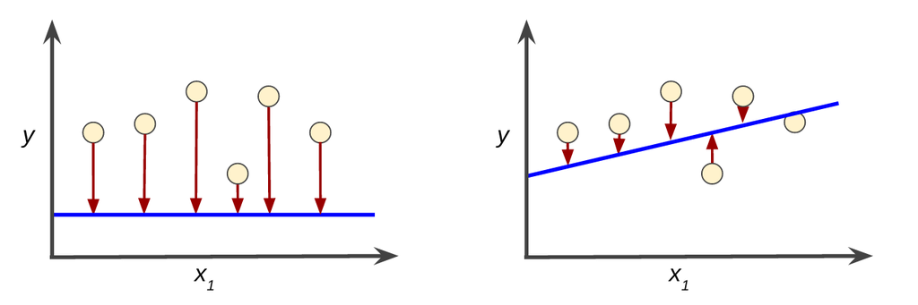

**Tujuan kita** adalah menghasilkan *garis regresi yang mendekati pola titik-titik data yang sesungguhnya dengan kesalahan sekecil mungkin*.

**Dua tipe Machine Learning Regresi Secara Umum**

1. **Model Regresi Statistik**, seperti Linear, Non-Linear, Ridge, Lasso, dll
2. **Model Regresi dengan Jaringan Syaraf Tiruan** (Di Bahas Nanti Yaa)

### Import Library

```r
if(!require(tidyverse)) install.packages("tidyverse")
if(!require(skimr)) install.packages("skimr")
if(!require(DataExplorer)) install.packages("DataExplorer")
if(!require(visdat)) install.packages("visdat")
```

```r
if(!require(heatmaply)) install.packages("heatmaply")
```

[output not shown]

```r
if(!require(psych)) install.packages("psych")
```

```r
library(heatmaply) #Untuk plot heatmap Missing Data
library(visdat)
library(tidyverse)
library(skimr)
library(DataExplorer)
library(dplyr)
library(ggplot2)
library(tidyr)
library(readr)
library(tibble)
library(reshape2) #Modifikasi DataFrame
library(psych) #Pair Plot
```

### Mengakses Dataset

```r
df<- read.csv("https://raw.githubusercontent.com/indracahyaramdani/PSDS-Kelas-Mahir-Python/main/Pertemuan%20Kedua/datacontoh.csv",stringsAsFactors = T)
df[df == ""] <- NA


head(df)
```

```
##   X Total.Salary Total.Compensation
## 1 0       680.04             864.81
## 2 1       680.04             864.81
## 3 2       680.04             864.81
## 4 3     48086.00           68719.23
## 5 4    107372.50          128181.28
## 6 5     32670.02           48908.27
```

```r
summary(df)
```

```
##        X           Total.Salary    Total.Compensation
##  Min.   :     0   Min.   :-33808   Min.   :-42615
##  1st Qu.:221525   1st Qu.:  5168   1st Qu.:  6914
##  Median :443051   Median : 53721   Median : 78738
##  Mean   :443051   Mean   : 59307   Mean   : 82944
##  3rd Qu.:664576   3rd Qu.: 93358   3rd Qu.:133802
##  Max.   :886101   Max.   :658868   Max.   :807175
```

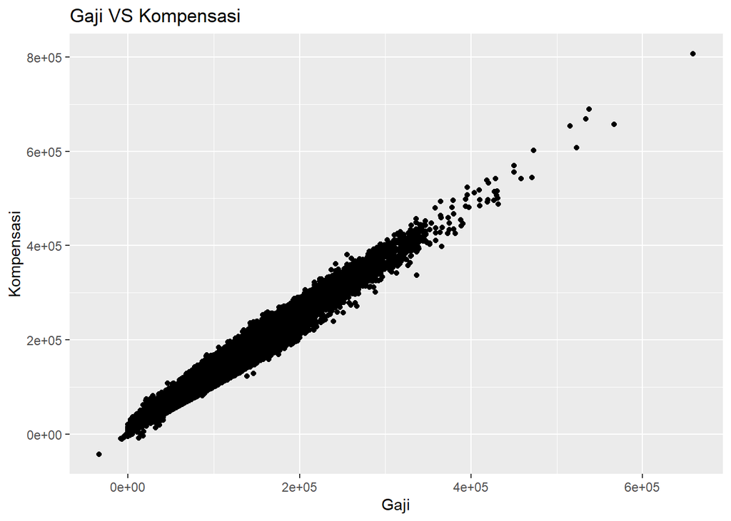

```r
g=ggplot(df,aes(Total.Salary,Total.Compensation))+geom_point()+
    labs(title = "Gaji VS Kompensasi",
        x = "Gaji",
        y = "Kompensasi")
g
```

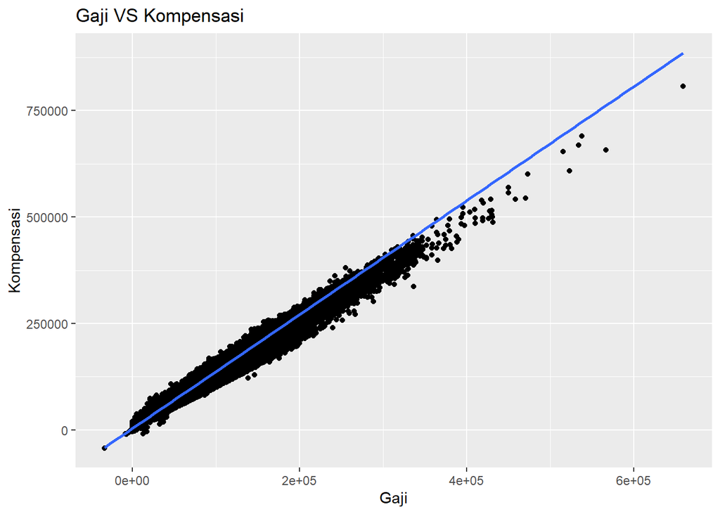

```r
#Membuat garis regresi
g1=ggplot(df,aes(Total.Salary,Total.Compensation))+geom_point()+geom_smooth(method="lm",se=T)+
    labs(title = "Gaji VS Kompensasi",
        x = "Gaji",
        y = "Kompensasi")
g1
```

Di atas terlihat dari grafik Gaji VS Kompensasi dilakukan prediksi nilai menggunakan regresi linear. Garis biru adalah hasil prediksi dari regresi linear

## **Mengakses Dataset**

```r
df_1  <- read.csv("https://raw.githubusercontent.com/indracahyaramdani/PSDS-Kelas-Mahir-Python/main/Pertemuan%20Kedua/train.csv", stringsAsFactors = T)
head(df_1)
```

```
##   X Unnamed..0 Id MSSubClass MSZoning LotFrontage LotArea Street Alley LotShape
## 1 0          0  1         60       RL          65    8450   Pave            Reg
## 2 1          1  2         20       RL          80    9600   Pave            Reg
## 3 2          2  3         60       RL          68   11250   Pave            IR1
## 4 3          3  4         70       RL          60    9550   Pave            IR1
## 5 4          4  5         60       RL          84   14260   Pave            IR1
## 6 5          5  6         50       RL          85   14115   Pave            IR1
##   LandContour Utilities LotConfig LandSlope Neighborhood Condition1 Condition2
## 1         Lvl    AllPub    Inside       Gtl      CollgCr       Norm       Norm
## 2         Lvl    AllPub       FR2       Gtl      Veenker      Feedr       Norm
## 3         Lvl    AllPub    Inside       Gtl      CollgCr       Norm       Norm
## 4         Lvl    AllPub    Corner       Gtl      Crawfor       Norm       Norm
## 5         Lvl    AllPub       FR2       Gtl      NoRidge       Norm       Norm
## 6         Lvl    AllPub    Inside       Gtl      Mitchel       Norm       Norm
##   BldgType HouseStyle OverallQual OverallCond YearBuilt YearRemodAdd RoofStyle
```

[output cut: 69 more lines]

## **Eksplorasi Data(Exploration Data Analysis)**

```r
dim(df_1)
```

```
## [1] 1460   83
```

### **Melihat statistik data**

```r
summary(df_1)
```

```
##        X            Unnamed..0           Id           MSSubClass
##  Min.   :   0.0   Min.   :   0.0   Min.   :   1.0   Min.   : 20.0
##  1st Qu.: 364.8   1st Qu.: 364.8   1st Qu.: 365.8   1st Qu.: 20.0
##  Median : 729.5   Median : 729.5   Median : 730.5   Median : 50.0
##  Mean   : 729.5   Mean   : 729.5   Mean   : 730.5   Mean   : 56.9
##  3rd Qu.:1094.2   3rd Qu.:1094.2   3rd Qu.:1095.2   3rd Qu.: 70.0
##  Max.   :1459.0   Max.   :1459.0   Max.   :1460.0   Max.   :190.0
##
##     MSZoning     LotFrontage        LotArea        Street      Alley
##  C (all):  10   Min.   : 21.00   Min.   :  1300   Grvl:   6       :1369
##  FV     :  65   1st Qu.: 59.00   1st Qu.:  7554   Pave:1454   Grvl:  50
##  RH     :  16   Median : 69.00   Median :  9478               Pave:  41
##  RL     :1151   Mean   : 70.05   Mean   : 10517
##  RM     : 218   3rd Qu.: 80.00   3rd Qu.: 11602
##                 Max.   :313.00   Max.   :215245
##                 NA's   :259
##  LotShape  LandContour  Utilities      LotConfig    LandSlope   Neighborhood
##  IR1:484   Bnk:  63    AllPub:1459   Corner : 263   Gtl:1382   NAmes  :225
##  IR2: 41   HLS:  50    NoSeWa:   1   CulDSac:  94   Mod:  65   CollgCr:150
##  IR3: 10   Low:  36                  FR2    :  47   Sev:  13   OldTown:113
##  Reg:925   Lvl:1311                  FR3    :   4              Edwards:100
##                                      Inside :1052              Somerst: 86
##                                                                Gilbert: 79
##                                                                (Other):707
##    Condition1     Condition2     BldgType      HouseStyle   OverallQual
##  Norm   :1260   Norm   :1445   1Fam  :1220   1Story :726   Min.   : 1.000
##  Feedr  :  81   Feedr  :   6   2fmCon:  31   2Story :445   1st Qu.: 5.000
##  Artery :  48   Artery :   2   Duplex:  52   1.5Fin :154   Median : 6.000
##  RRAn   :  26   PosN   :   2   Twnhs :  43   SLvl   : 65   Mean   : 6.099
##  PosN   :  19   RRNn   :   2   TwnhsE: 114   SFoyer : 37   3rd Qu.: 7.000
##  RRAe   :  11   PosA   :   1                 1.5Unf : 14   Max.   :10.000
##  (Other):  15   (Other):   2                 (Other): 19
##   OverallCond      YearBuilt     YearRemodAdd    RoofStyle       RoofMatl
##  Min.   :1.000   Min.   :1872   Min.   :1950   Flat   :  13   CompShg:1434
##  1st Qu.:5.000   1st Qu.:1954   1st Qu.:1967   Gable  :1141   Tar&Grv:  11
##  Median :5.000   Median :1973   Median :1994   Gambrel:  11   WdShngl:   6
##  Mean   :5.575   Mean   :1971   Mean   :1985   Hip    : 286   WdShake:   5
##  3rd Qu.:6.000   3rd Qu.:2000   3rd Qu.:2004   Mansard:   7   ClyTile:   1
##  Max.   :9.000   Max.   :2010   Max.   :2010   Shed   :   2   Membran:   1
##                                                               (Other):   2
```

[output cut: 81 more lines]

```
##      :1406   Min.   :    0.00   Min.   : 1.000   Min.   :2006   WD     :1267
##  Gar2:   2   1st Qu.:    0.00   1st Qu.: 5.000   1st Qu.:2007   New    : 122
##  Othr:   2   Median :    0.00   Median : 6.000   Median :2008   COD    :  43
##  Shed:  49   Mean   :   43.49   Mean   : 6.322   Mean   :2008   ConLD  :   9
##  TenC:   1   3rd Qu.:    0.00   3rd Qu.: 8.000   3rd Qu.:2009   ConLI  :   5
##              Max.   :15500.00   Max.   :12.000   Max.   :2010   ConLw  :   5
##                                                                 (Other):   9
##  SaleCondition    SalePrice
##  Abnorml: 101   Min.   : 34900
##  AdjLand:   4   1st Qu.:129975
##  Alloca :  12   Median :163000
##  Family :  20   Mean   :180921
##  Normal :1198   3rd Qu.:214000
##  Partial: 125   Max.   :755000
##
```

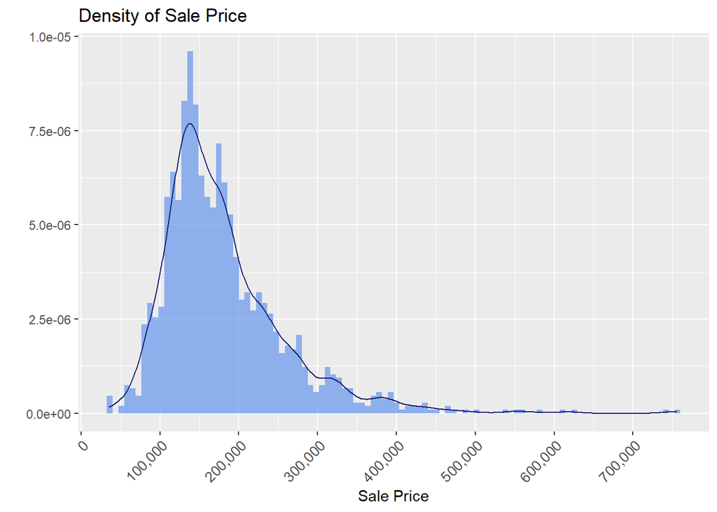

```r
#Melihat distribusi kolom target(harga rumah)
p1 <- df_1 %>%
  ggplot(aes(x = SalePrice)) +
  geom_histogram(aes(x = SalePrice, stat(density)),
                 bins = 100,
                 fill = "cornflowerblue",
                 alpha = 0.7) +
  geom_density(color = "midnightblue") +
  scale_x_continuous(breaks= seq(0, 800000, by=100000), labels = scales::comma) +
  labs(x = "Sale Price", y = "", title = "Density of Sale Price") +
  theme(axis.text.x = element_text(size = 10, angle = 45, hjust = 1))
p1
```

```r
#Melihat inforsimasi kolom dataset
str(df_1)
```

```
## 'data.frame':    1460 obs. of  83 variables:
##  $ X            : int  0 1 2 3 4 5 6 7 8 9 ...
##  $ Unnamed..0   : int  0 1 2 3 4 5 6 7 8 9 ...
##  $ Id           : int  1 2 3 4 5 6 7 8 9 10 ...
##  $ MSSubClass   : int  60 20 60 70 60 50 20 60 50 190 ...
##  $ MSZoning     : Factor w/ 5 levels "C (all)","FV",..: 4 4 4 4 4 4 4 4 5 4 ...
##  $ LotFrontage  : num  65 80 68 60 84 85 75 NA 51 50 ...
##  $ LotArea      : int  8450 9600 11250 9550 14260 14115 10084 10382 6120 7420 ...
##  $ Street       : Factor w/ 2 levels "Grvl","Pave": 2 2 2 2 2 2 2 2 2 2 ...
##  $ Alley        : Factor w/ 3 levels "","Grvl","Pave": 1 1 1 1 1 1 1 1 1 1 ...
##  $ LotShape     : Factor w/ 4 levels "IR1","IR2","IR3",..: 4 4 1 1 1 1 4 1 4 4 ...
##  $ LandContour  : Factor w/ 4 levels "Bnk","HLS","Low",..: 4 4 4 4 4 4 4 4 4 4 ...
##  $ Utilities    : Factor w/ 2 levels "AllPub","NoSeWa": 1 1 1 1 1 1 1 1 1 1 ...
##  $ LotConfig    : Factor w/ 5 levels "Corner","CulDSac",..: 5 3 5 1 3 5 5 1 5 1 ...
##  $ LandSlope    : Factor w/ 3 levels "Gtl","Mod","Sev": 1 1 1 1 1 1 1 1 1 1 ...
```

[output cut: 69 more lines]

# Melihat nilai korelasi antar variable factor

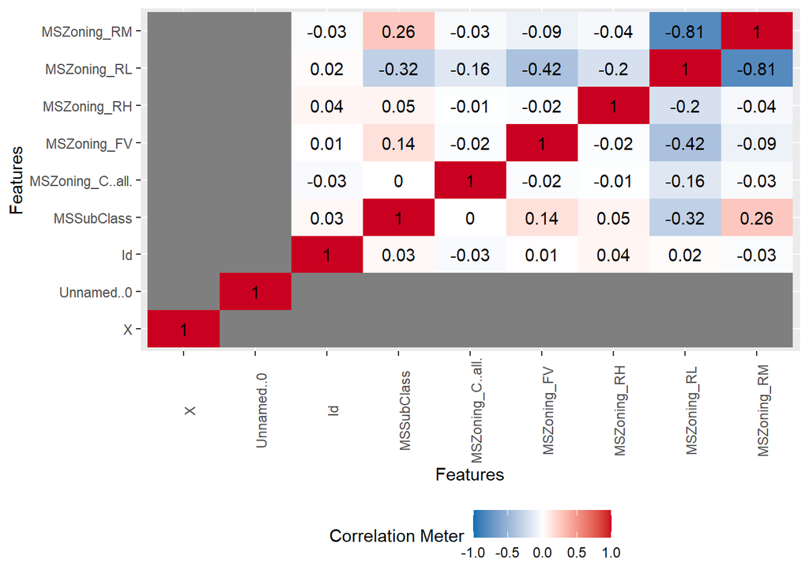

```r
df_1[1:5] %>%
  mutate_if(is.numeric, log) %>%
  plot_correlation()
```

## **Data Cleaning**

Data cleansing atau data cleaning merupakan suatu proses mendeteksi dan memperbaiki (atau menghapus) suatu record yang ‘corrupt’ atau tidak akurat berdasarkan sebuah record set, tabel, atau database. Agar mempunyai struktur yang lebih baik.

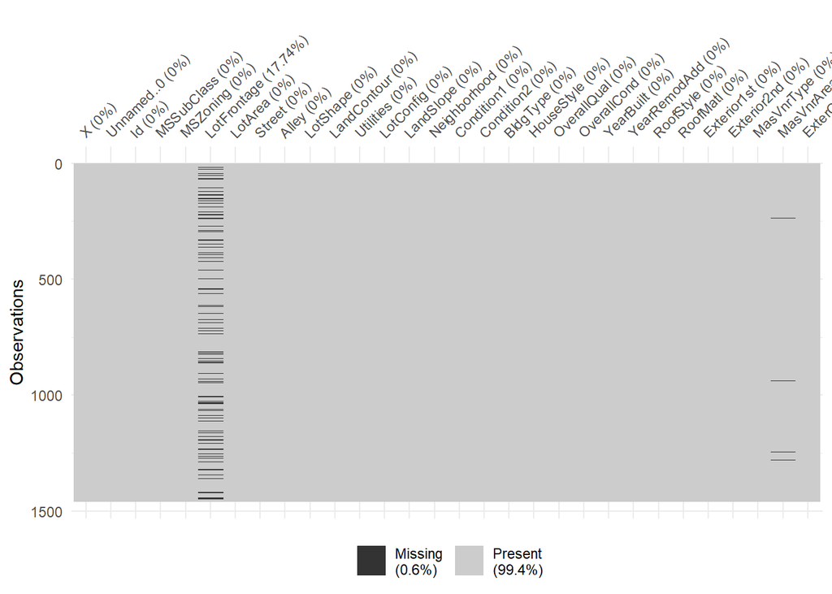

```r
##Mengisi missing value

vis_miss (df_1[1:30])    #Melihat Missing Value
```

*Memperbaiki nilai yang hilang pada kolom LotFrontage*

```r
df_1$LotFrontage=ifelse(is.na(df_1$LotFrontage),
                        ave(df_1$LotFrontage,FUN=function(x) mean(x,na.rm=TRUE)),
                        df_1$LotFrontage)
```

## **Membangun Model Regresi**

```r
model = lm(X~SalePrice, data=df_1)
summary(model)
```

```
##
## Call:
## lm(formula = X ~ SalePrice, data = df_1)
##
## Residuals:
##     Min      1Q  Median      3Q     Max
## -731.26 -364.70    1.85  360.51  737.45
##
## Coefficients:
##               Estimate Std. Error t value Pr(>|t|)
## (Intercept)  7.505e+02  2.746e+01  27.337   <2e-16 ***
## SalePrice   -1.163e-04  1.390e-04  -0.837    0.403
## ---
## Signif. codes:  0 '***' 0.001 '**' 0.01 '*' 0.05 '.' 0.1 ' ' 1
##
## Residual standard error: 421.7 on 1458 degrees of freedom
## Multiple R-squared:  0.0004803,  Adjusted R-squared:  -0.0002052
## F-statistic: 0.7007 on 1 and 1458 DF,  p-value: 0.4027
```

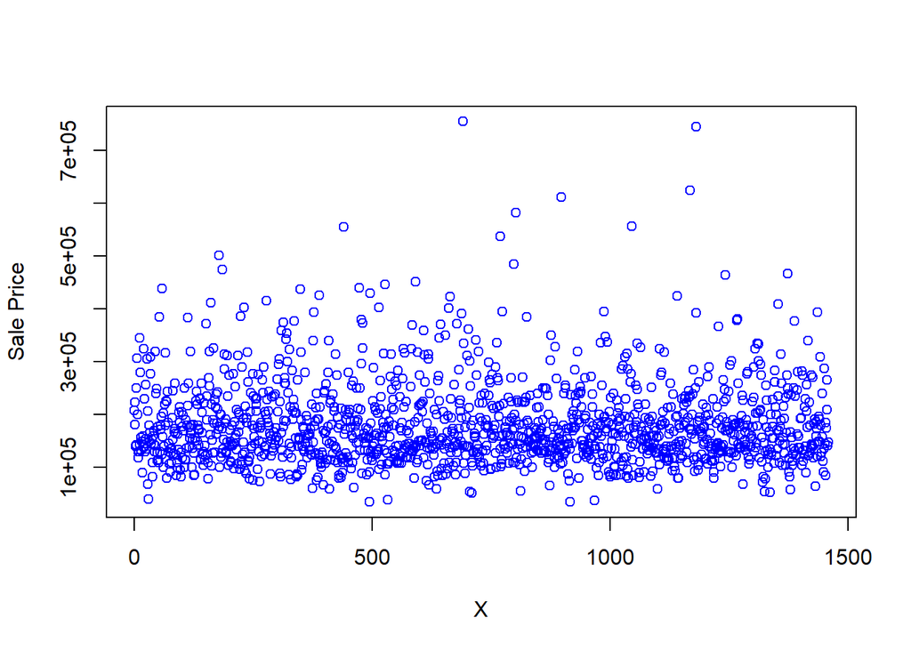

```r
g1= plot(df_1$X,df_1$SalePrice,xlab = "X",ylab ="Sale Price",col="blue")
abline(lm(df_1$X~df_1$SalePrice),col="red")
```